# Me stalkee en Twitter

Alberto Macías

6/7/2021

```r
library(dplyr)
library(lubridate)
library(ggplot2)
library(gridExtra)

library(tidytext)
library(twitteR)
library(tm)
library(tokenizers)
library(wordcloud)
library(RColorBrewer)
```

A veces me stalkeo, para acordarme quién soy. Este ha sido uno de mis tuits más populares, desde hace ya casi cuatro años y, en cierta forma, sigo creyendo en eso. A lo que me refiero es que muchos acostumbramos compartir lo que sentimos o pensamos, de casi cualquier cosa, en redes sociales y, de vez en cuando, es buena idea revisar lo que escribimos para recordar quiénes hemos sido y evaluar cómo hemos cambiado. La etimología de “recordar” es algo como “volver a pasar por el corazón” y no sé ustedes, pero yo creo que de vez en cuando es bueno releer las angustias y los desamores, o el entusiasmo y la alegría, para saber dónde hemos estado y hacia dónde vamos. Ya lo dijo Heráclito, un hombre no escribe el mismo tuits dos veces, porque ya no es el mismo hombre ni el mismo tuit. O algo sobre ríos, ya no me acuerdo.

Una vez planteada esta premisa, quedan dos alternativas: pasar un par de horas haciendo scroll en nuestro perfil de Twitter o pasar un par de horas escribiendo código y descubrir algunos datos interesantes. Dado que tengo que aprender sobre procesamiento del lenguaje natural en R y con eso de que “debemos ser productivos”, he optado por la segunda.

Para este texto, ocuparé la librería *twitterR*

```r
tuits_df <- read.csv("tuits_bhherto95.csv")
tuits_df <- tuits_df[,-1]
tuits_df$created <- as_datetime(tuits_df$created)
```

Por alguna razón que no acabo de comprender, si no incluyo los retuits y luego los excluyo del data frame solo puedo descargar 37 tuits

Mi análisis consiste en lo siguiente:

- Distribución de favs y retuits
- Serie temporal de favs y retuits
- Análisis de las palabras que más tuiteo
- Análisis de los favs de algunas de las palabras más usadas

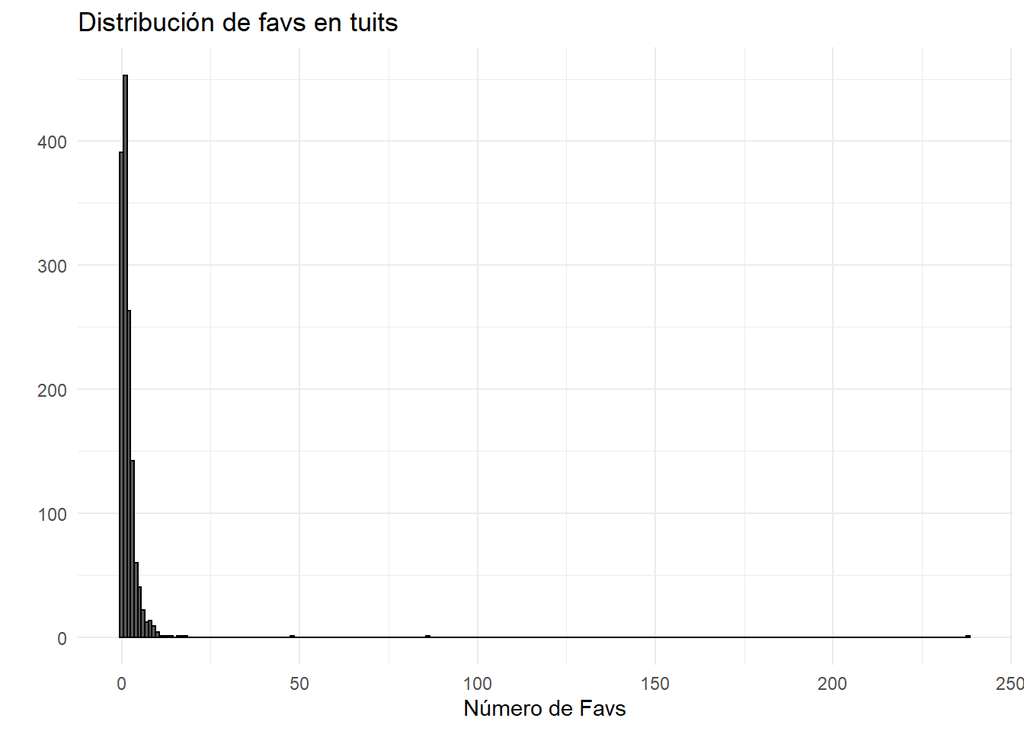

```r
tuits_df %>% ggplot(aes(x=favoriteCount))+
            geom_histogram(binwidth = 1, color="black")+
            theme_minimal()+
            labs(title="Distribución de favs en tuits",
                 x="Número de Favs",
                 y="")
```

```r
summary(tuits_df$favoriteCount)
```

```
##    Min. 1st Qu.  Median    Mean 3rd Qu.    Max.
##   0.000   0.000   1.000   1.944   2.000 238.000
```

```r
table(tuits_df$favoriteCount)
```

```
##
##   0   1   2   3   4   5   6   7   8   9  10  11  12  13  14  16  17  18  48  86
## 391 453 263 142  60  40  22  12  13   9   4   1   1   1   1   1   1   1   1   1
## 238
##   1
```

Todos los datos mayores a 11 son outliers, en especial los dos más grandes y conozco el motivo de que estos hayan tenido tantos favs

```r
tuits_df[tuits_df$favoriteCount==238,]$text
```

[output not shown]

```r
tuits_df[tuits_df$favoriteCount==86,]$text
```

```
## [1] "@ferblanchett1 Te voy a seguir porque siento que de aquí va a salir algo boñito y me quiero enterar del chisme.\n\nAs… https://t.co/NOWYquQe6y"
```

```r
tuits_df[tuits_df$favoriteCount==48,]$text
```

```
## [1] "Estudiar matemáticas be like... https://t.co/YeCAkPOUIu"
```

```r
tuits_df[tuits_df$favoriteCount==18,]$text
```

```
## [1] "what = pa'\nthe = su\nfuck = mecha"
```

```r
tuits_df[tuits_df$favoriteCount==17,]$text
```

```
## [1] "Maldita pandemia, si hubiera querido desperdiciar mis años 20's hubiera estudiado una carrera en la que tengo que e… https://t.co/32sQCCCEkO"
```

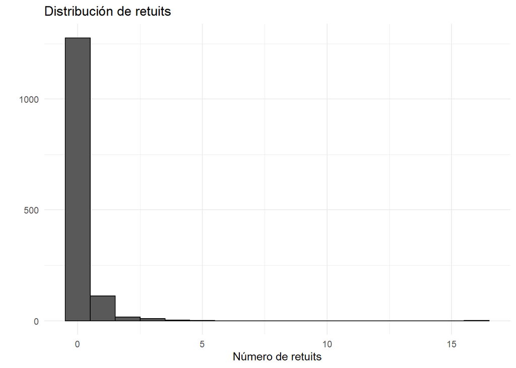

```r
tuits_df %>% ggplot(aes(x=retweetCount))+
            geom_histogram(binwidth = 1, color="black")+
            theme_minimal()+
            labs(title="Distribución de retuits",
                 x="Número de retuits",
                 y="")
```

```r
summary(tuits_df$retweetCount)
```

```
##    Min. 1st Qu.  Median    Mean 3rd Qu.    Max.
##  0.0000  0.0000  0.0000  0.1452  0.0000 16.0000
```

```r
table(tuits_df$retweetCount)
```

```
##
##    0    1    2    3    4    5   16
## 1276  112   17    9    3    1    1
```

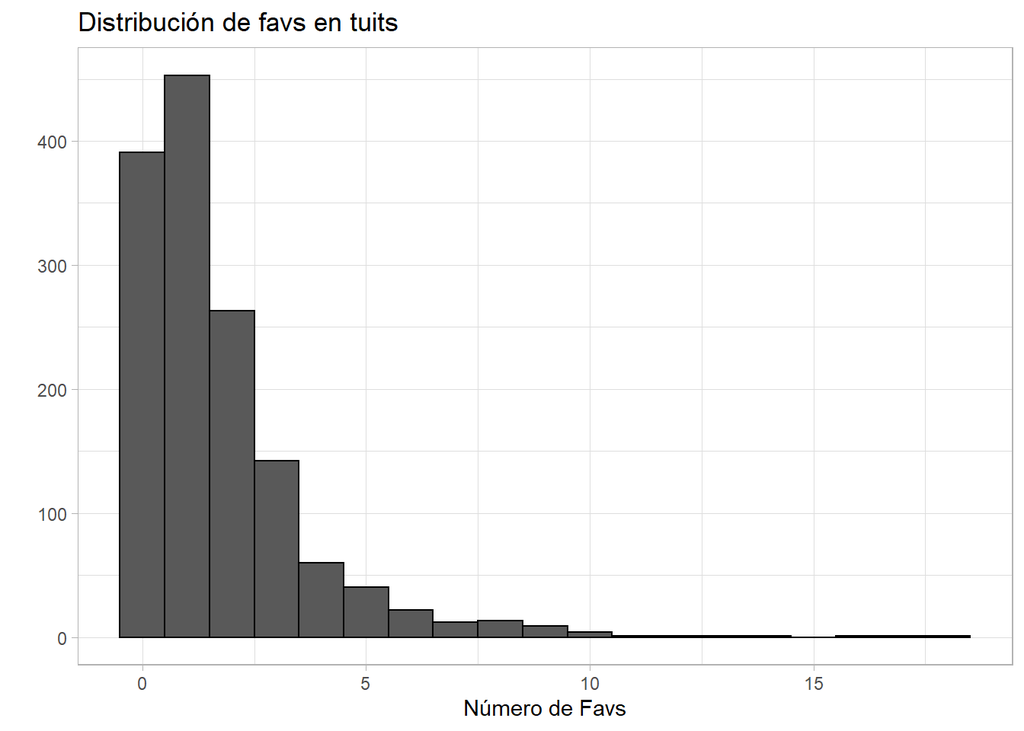

```r
tuits_df <- tuits_df %>% filter(favoriteCount<20)

tuits_df %>% ggplot(aes(x=favoriteCount))+
            geom_histogram(binwidth = 1, color="black")+
            theme_light()+
            labs(title="Distribución de favs en tuits",
                 x="Número de Favs",
                 y="")
```

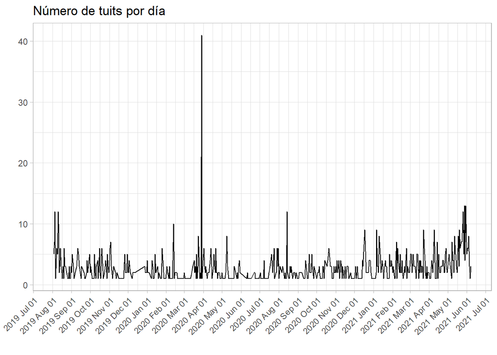

```r
tuits_df %>% mutate(fecha=as.Date(created)) %>%
            group_by(fecha) %>% summarise(tuits = n()) %>%
            ggplot(aes(x=fecha, y=tuits))+
            geom_line()+
            theme_light()+
            labs(title = "Número de tuits por día",
                 x="",
                 y="")+
            scale_x_date(date_labels = "%Y %b %d", date_breaks = "1 month")+
            theme(axis.text.x = element_text(angle = 45, hjust = 1))
```

Notemos que hay un pico muy grande en el número de tuits que publiqué al rededor de finales de marzo y principios de abril del 2020

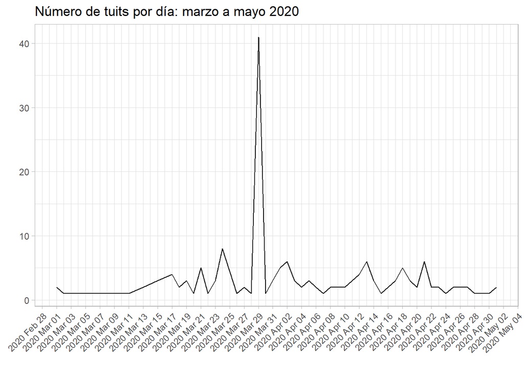

```r
tuits_df %>% mutate(fecha=as.Date(created)) %>%
            filter(fecha >= as.Date("2020-03-01") & fecha <= as.Date("2020-05-01"))%>%
            group_by(fecha) %>% summarise(tuits = n()) %>%
            ggplot(aes(x=fecha, y=tuits))+
            geom_line()+
            theme_light()+
            labs(title = "Número de tuits por día: marzo a mayo 2020",
                 x="",
                 y="")+
            scale_x_date(date_labels = "%Y %b %d", date_breaks = "2 day")+
            theme(axis.text.x = element_text(angle = 45, hjust = 1))
```

```r
tuits_df %>% mutate(fecha=as.Date(created)) %>%
            filter(fecha== as.Date("2020-03-30") ) %>%
            select(text, replyToSN)
```

```
##                                                                                                                                            text
## 1 Ahora que es cuaresma y por si andan en la zona norte de la CDMX.\nUno de los chefs es mi mejor amigo y se rifa much… https://t.co/sPSyEnftvh
##   replyToSN
## 1      <NA>
```

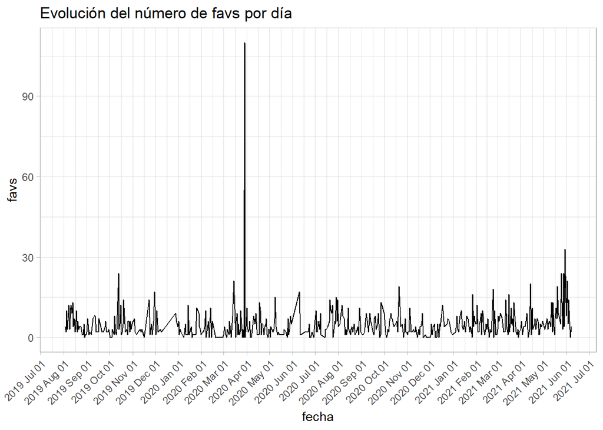

```r
tuits_df %>% mutate(fecha=as.Date(created)) %>%
            group_by(fecha) %>% summarise(favs = sum(favoriteCount)) %>%
            ggplot(aes(x=fecha, y=favs))+
            geom_line()+
            theme_light()+
            labs(title = "Evolución del número de favs por día")+
            scale_x_date(date_labels = "%Y %b %d", date_breaks = "1 month")+
            theme(axis.text.x = element_text(angle = 45, hjust = 1))
```

Notemos que hay un pico en el conteo de favoritos de ese día, que corresponden al mismo evento. Nos concentramos solo en los tuits de este año

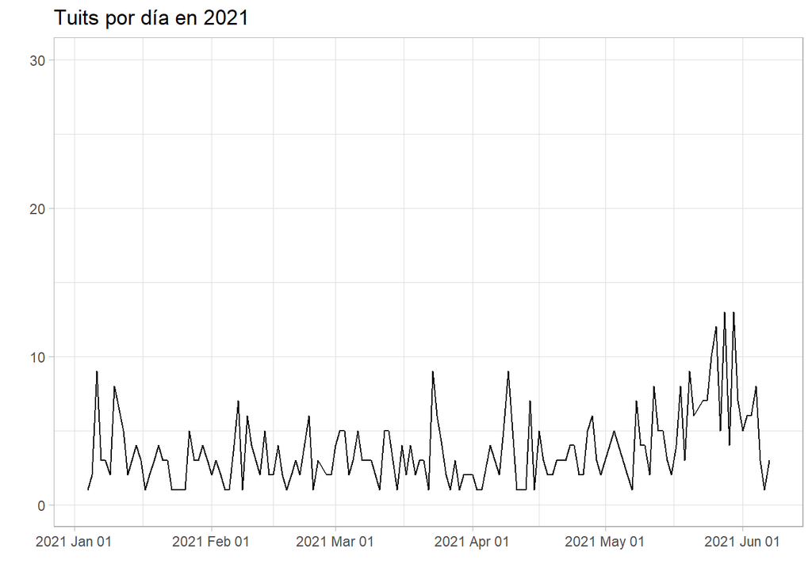

```r
p1 <- tuits_df %>% filter(created>=as.Date("2021-01-01")) %>%
            mutate(fecha=as.Date(created)) %>%
            group_by(fecha) %>% summarise(tuits = n()) %>%
            ggplot(aes(x=fecha, y=tuits))+
            geom_line()+
            theme_light()+
            labs(title="Tuits por día en 2021",
                 x="",
                 y="")+
            scale_x_date(date_labels = "%Y %b %d", date_breaks = "1 month")+
            ylim(0,30)
p1
```

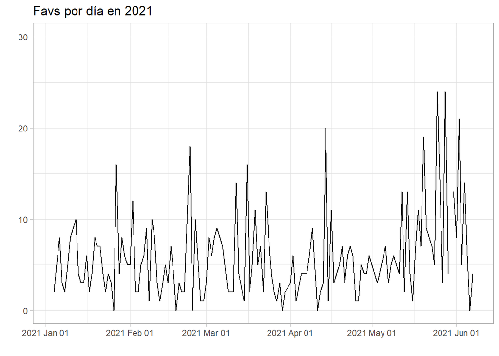

```r
p2 <- tuits_df %>% filter(created>=as.Date("2021-01-01")) %>%
            mutate(fecha=as.Date(created)) %>%
            group_by(fecha) %>% summarise(favs = sum(favoriteCount)) %>%
            ggplot(aes(x=fecha, y=favs))+
            geom_line()+
            theme_light()+
            labs(title="Favs por día en 2021",
                 x="",
                 y="")+
            scale_x_date(date_labels = "%Y %b %d", date_breaks = "1 month")+
            ylim(0,30)
p2
```

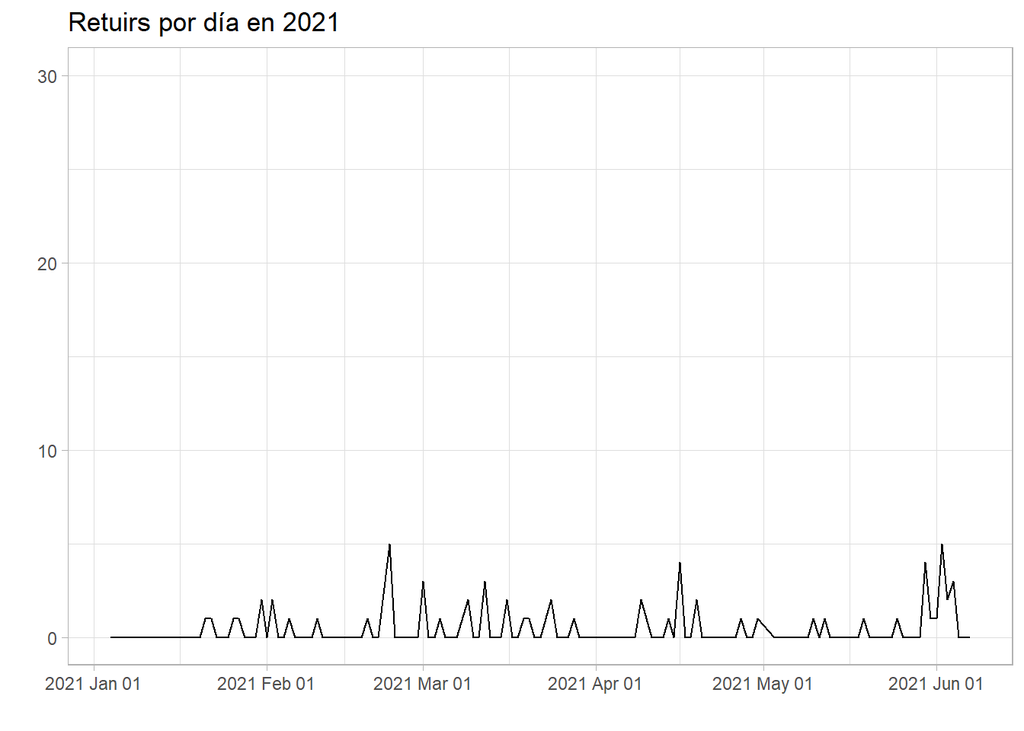

```r
p3 <- tuits_df %>% filter(created>=as.Date("2021-01-01")) %>%
            mutate(fecha=as.Date(created)) %>%
            group_by(fecha) %>% summarise(retuits = sum(retweetCount)) %>%
            ggplot(aes(x=fecha, y=retuits))+
            geom_line()+
            theme_light()+
            labs(title="Retuirs por día en 2021",
                 x="",
                 y="")+
            scale_x_date(date_labels = "%Y %b %d", date_breaks = "1 month")+
            ylim(0,30)
p3
```

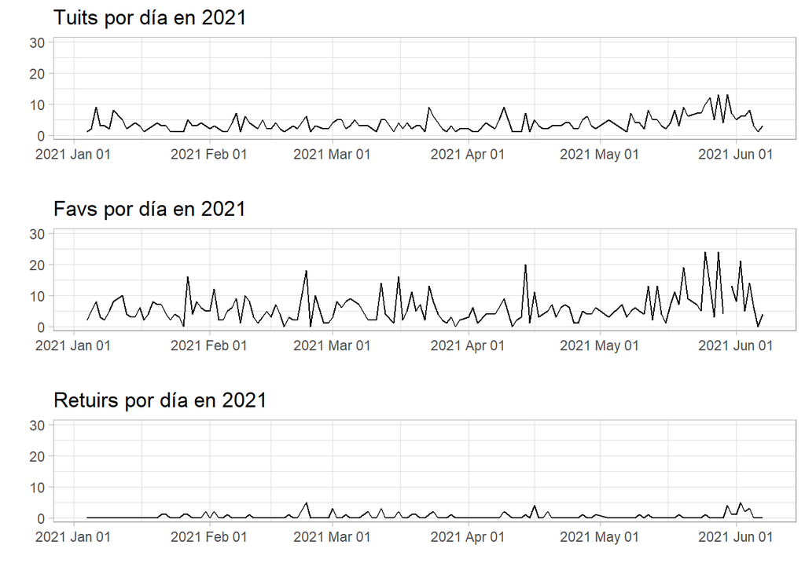

```r
grid.arrange(p1,p2, p3, nrow=3)
```

Notemos que hubo cierta tendencia a la alza en el número de tuits y favs durante el mes de mayo que se detuvo a principios de junio.

Ahora estoy interesado en averiguar en qué días, en promedio, obtengo más favs

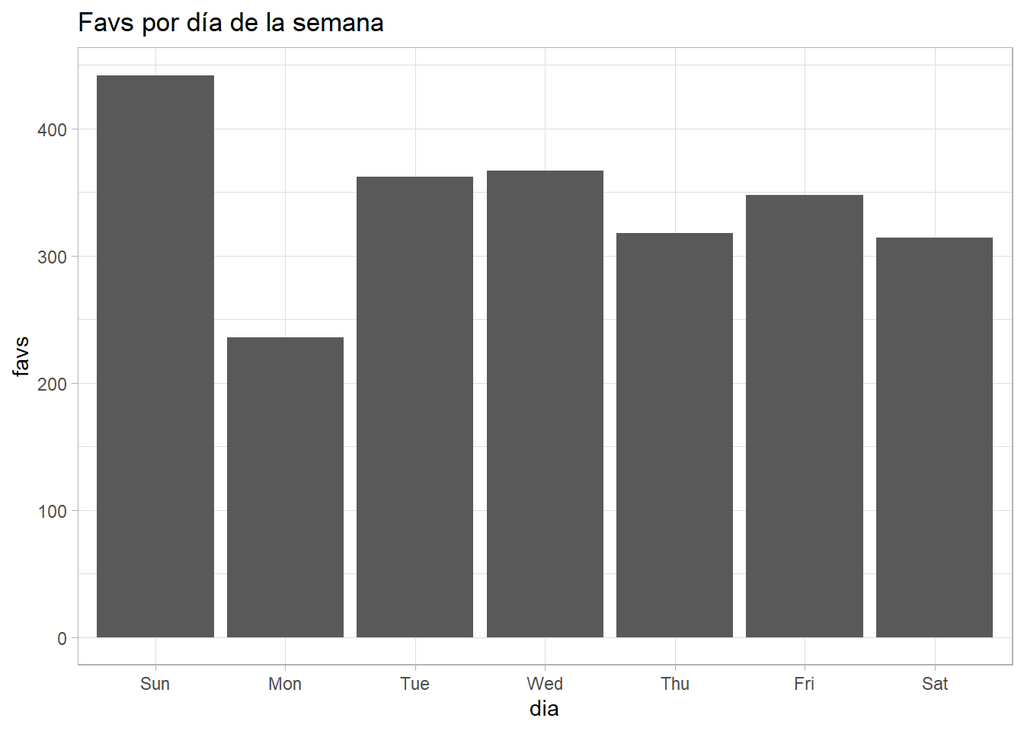

```r
tuits_df %>% mutate(dia = wday(created, label = TRUE)) %>%
            group_by(dia) %>%
            summarise(favs = sum(favoriteCount)) %>%
            ggplot(aes(x=dia, y=favs)) +
            geom_bar(stat = "identity")+
            theme_light()+
            labs(title = "Favs por día de la semana ")
```

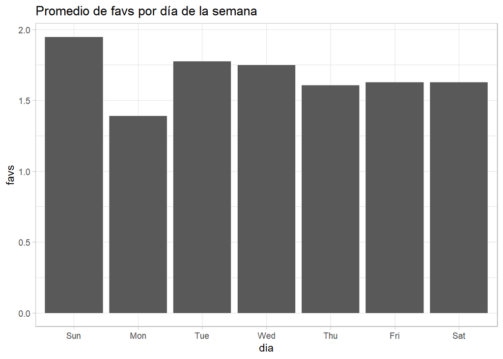

```r
tuits_df %>% mutate(dia = wday(created, label = TRUE)) %>%
            group_by(dia) %>%
            summarise(favs = mean(favoriteCount)) %>%
            ggplot(aes(x=dia, y=favs)) +
            geom_bar(stat = "identity")+
            theme_light()+
            labs(title = "Promedio de favs por día de la semana ")
```

Este mismo análisis se puede hacer por hora del día

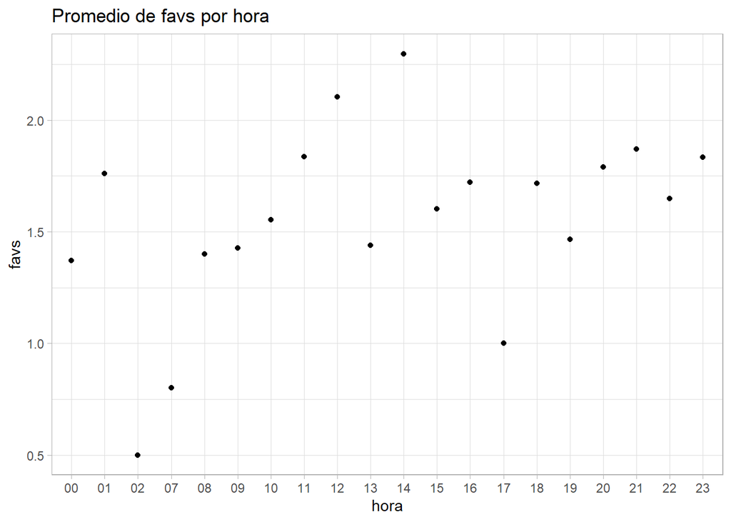

```r
tuits_df %>% mutate(hora = format(as.POSIXct(created,format="%H:%M:%S"
                                             ),"%H")) %>%
            group_by(hora) %>%
            summarise(favs=mean(favoriteCount))%>%
            ggplot(aes(x=hora, y=favs))+
            geom_point()+
            theme_light()+
            labs(title = "Promedio de favs por hora")
```

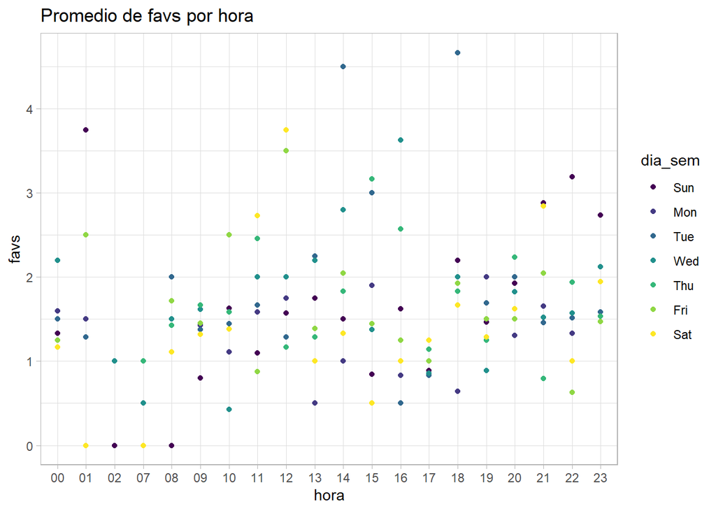

```r
tuits_df %>% mutate(hora = format(as.POSIXct(created,format="%H:%M:%S"),"%H"),
                          dia_sem = wday(created, label = T)) %>%
            group_by(hora, dia_sem) %>%
            summarise(favs=mean(favoriteCount))%>%
            ggplot(aes(x=hora, y=favs, color=dia_sem))+
            geom_point()+
            theme_light()+
            labs(title = "Promedio de favs por hora")
```

¿De qué es lo que hablo más en mi Twitter?

```r
tuits_corpus <- Corpus(VectorSource(tuits_df$text),
                        readerControl = list(readPlain, language="sp", load=TRUE))
```

```r
tuits_corpus <- tm_map(tuits_corpus, content_transformer(tolower))
tuits_corpus <- tm_map(tuits_corpus, removePunctuation)
tuits_corpus <- tm_map(tuits_corpus, removeNumbers)
tuits_corpus <- tm_map(tuits_corpus, removeWords, stopwords("spanish"))
inspect(tuits_corpus[1:5])
```

```
## <<SimpleCorpus>>
## Metadata:  corpus specific: 1, document level (indexed): 0
## Content:  documents: 5
##
## [1]  primera vez  toda  especialización alguien  chuleó  reporte\n\n   conmueve      leyó
## [2] natszendro reactor  menos   victoria después   elecciones ufaufaufa
## [3] oigan    temprano   fiesta ¿quién rompió  lavabo ah    acordé\n\ndejó   pan ganara tantas alcaldías
## [4] feliz día   simulación ¿  trajo  hada  ine además  ansiedad  incertidumbre
## [5] elizabethrial httpstcoephcfsc
```

```r
subs <- function(s){
            s <- sub("¿", "", s)
            s <- sub("https*", "", s)
            return(s)
}

tuits_corpus <- tm_map(tuits_corpus, content_transformer(subs))
tuits_corpus <- tm_map(tuits_corpus, stripWhitespace)
inspect(tuits_corpus[1:5])
```

```
## <<SimpleCorpus>>
## Metadata:  corpus specific: 1, document level (indexed): 0
## Content:  documents: 5
##
## [1]  primera vez toda especialización alguien chuleó reporte conmueve leyó
## [2] natszendro reactor menos victoria después elecciones ufaufaufa
## [3] oigan temprano fiesta quién rompió lavabo ah acordé dejó pan ganara tantas alcaldías
## [4] feliz día simulación trajo hada ine además ansiedad incertidumbre
## [5] elizabethrial tcoephcfsc
```

```r
tuits_dtm <- tokenize_ngrams(sapply(tuits_corpus, as.character), n=1)
tuits_dtm <- unlist(tuits_dtm)
tuits_dtm <- data.frame(table(tuits_dtm))
tuits_dtm <- arrange(tuits_dtm, desc(Freq))
head(tuits_dtm, 15)
```

```
##        tuits_dtm Freq
## 1  diagramadeven  103
## 2             uf   89
## 3             si   88
## 4            hoy   67
## 5            voy   60
## 6              d   56
## 7           bien   54
## 8    elcancerend   49
## 9          hacer   46
## 10        jajaja   46
## 11           ser   46
## 12           día   44
## 13 esteusermurio   43
## 14          creo   40
## 15          cómo   39
```

```r
my_stopwords <- c("si", "d")
tuits_corpus <- tm_map(tuits_corpus, removeWords, my_stopwords)
tuits_corpus <- tm_map(tuits_corpus, stripWhitespace)
tuits_dtm <- tokenize_ngrams(sapply(tuits_corpus, as.character), n=1)
tuits_dtm <- unlist(tuits_dtm)
tuits_dtm <- data.frame(table(tuits_dtm))
tuits_dtm <- arrange(tuits_dtm, desc(Freq))
head(tuits_dtm, 15)
```

```
##        tuits_dtm Freq
## 1  diagramadeven  103
## 2             uf   89
## 3            hoy   67
## 4            voy   60
## 5           bien   54
## 6    elcancerend   49
## 7          hacer   46
## 8         jajaja   46
## 9            ser   46
## 10           día   44
## 11 esteusermurio   43
## 12          creo   40
## 13          cómo   39
## 14           así   38
## 15         curso   36
```

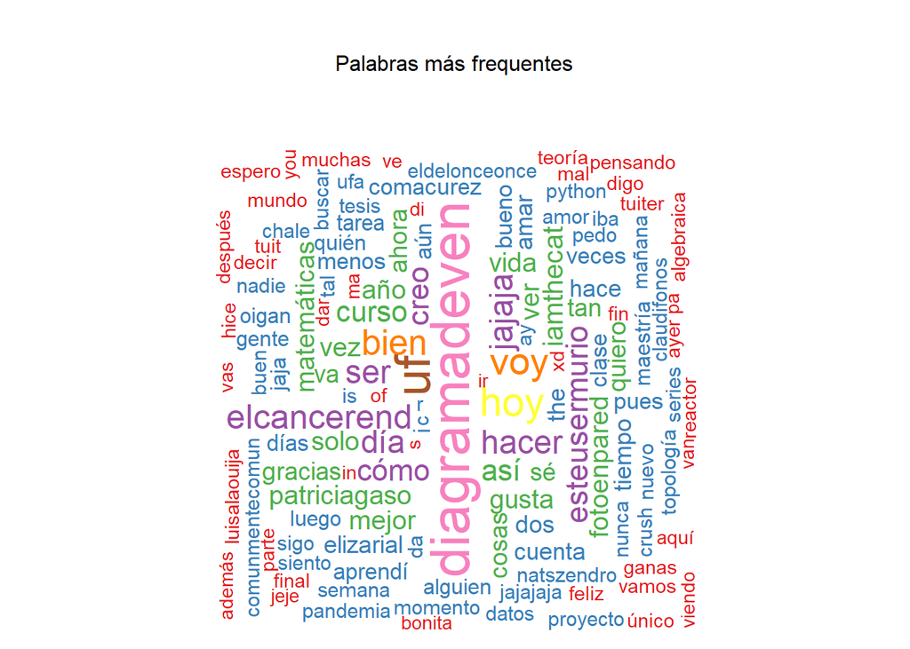

```r
colnames(tuits_dtm) <- c("word", "freq")
tuits_dtm$word <- as.character(tuits_dtm$word)
layout(matrix(c(1, 2), nrow=2), heights=c(1, 4))
par(mar=rep(0, 4))
plot.new()
text(x=0.5, y=0.5, "Palabras más frequentes")
wordcloud(words = tuits_dtm$word, freq = tuits_dtm$freq,
          main ="Title", min.freq = 10,max.words = 200,
          random.order = F, rot.per = 0.35,
          colors = brewer.pal(8, "Set1"),
          scale = c(2.5,0.7))
```

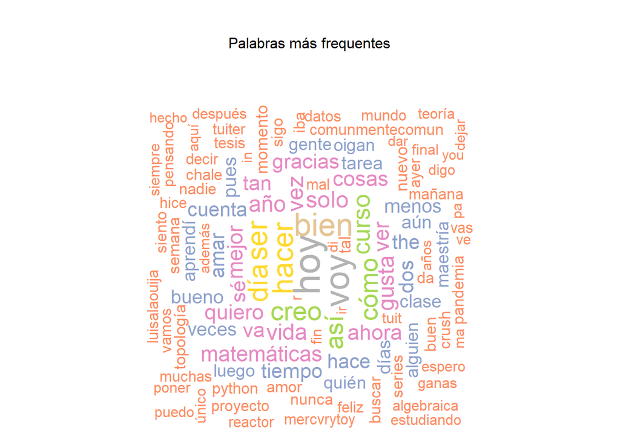

```r
my_stopwords <- c("si", "d", "diagramadeven", "esteusermurio", "comacurez", "elcancerend",
                  "jajajaja", "jejeje", "xd", "jajaja", "jeje", "c", "natszendro",
                  "ay", "fotoenpared", "elizarial", "iamthecat", "patriciagaso",
                  "i", "s", "is","of", "jaja","claudifonos", "eldelonceonce",
                  "uf", "ufa", "pedo")
tuits_corpus <- tm_map(tuits_corpus, removeWords, my_stopwords)
tuits_corpus <- tm_map(tuits_corpus, stripWhitespace)
tuits_dtm <- tokenize_ngrams(sapply(tuits_corpus, as.character), n=1)
tuits_dtm <- unlist(tuits_dtm)
tuits_dtm <- data.frame(table(tuits_dtm))
tuits_dtm <- arrange(tuits_dtm, desc(Freq))
colnames(tuits_dtm) <- c("word", "freq")
tuits_dtm$word <- as.character(tuits_dtm$word)

layout(matrix(c(1, 2), nrow=2), heights=c(1, 4))
par(mar=rep(0, 4))
plot.new()
text(x=0.5, y=0.5, "Palabras más frequentes")
wordcloud(words = tuits_dtm$word, freq = tuits_dtm$freq,
          main ="Title", min.freq = 10,max.words = 200,
          random.order = F, rot.per = 0.35,
          colors = brewer.pal(8, "Set2"),
          scale = c(2.5,0.7))
```

```r
tuits_df$texto_limpio <- sapply(tuits_corpus, as.character)
```

Finalmente, estoy interesado en saber el impacto de ciertos temas en el propedio de favs que recubo.

```r
tuits_df$matematicas <- grepl("matemáticas", tuits_df$texto_limpio)
tuits_df$python <- grepl("python", tuits_df$texto_limpio)
tuits_df$topologia <- grepl("topología", tuits_df$texto_limpio)
tuits_df$tesis <- grepl("tesis", tuits_df$texto_limpio)
tuits_df$crush <- grepl("crush", tuits_df$texto_limpio)
tuits_df$amor <- grepl("amor", tuits_df$texto_limpio)
```

```r
print("Estadísdicas generales de mis tuits:")
```

```
## [1] "Estadísdicas generales de mis tuits:"
```

```r
summary(tuits_df$favoriteCount)
```

```
##    Min. 1st Qu.  Median    Mean 3rd Qu.    Max.
##   0.000   0.000   1.000   1.686   2.000  18.000
```

```r
print("Estadísticas de los favs en tuits de matemáticas:")
```

```
## [1] "Estadísticas de los favs en tuits de matemáticas:"
```

```r
summary(tuits_df$favoriteCount[tuits_df$matematicas])
```

```
##    Min. 1st Qu.  Median    Mean 3rd Qu.    Max.
##   0.000   1.000   2.000   3.379   5.000  10.000
```

```r
print("Estadísticas de los favs en tuits de python:")
```

```
## [1] "Estadísticas de los favs en tuits de python:"
```

```r
summary(tuits_df$favoriteCount[tuits_df$python])
```

```
##    Min. 1st Qu.  Median    Mean 3rd Qu.    Max.
##   1.000   2.000   2.000   2.611   3.000   6.000
```

```r
print("Estadísticas de los favs en tuits de toplogía:")
```

```
## [1] "Estadísticas de los favs en tuits de toplogía:"
```

```r
summary(tuits_df$favoriteCount[tuits_df$topologia])
```

```
##    Min. 1st Qu.  Median    Mean 3rd Qu.    Max.
##   0.000   0.250   1.000   2.071   3.500   8.000
```

```r
print("Estadísticas de los favs en tuits de tesis:")
```

```
## [1] "Estadísticas de los favs en tuits de tesis:"
```

```r
summary(tuits_df$favoriteCount[tuits_df$tesis])
```

```
##    Min. 1st Qu.  Median    Mean 3rd Qu.    Max.
##   0.000   1.000   1.000   2.118   3.000   9.000
```

```r
print("Estadísticas de los favs en tuits de crush:")
```

```
## [1] "Estadísticas de los favs en tuits de crush:"
```

```r
summary(tuits_df$favoriteCount[tuits_df$crush])
```

```
##    Min. 1st Qu.  Median    Mean 3rd Qu.    Max.
##   0.000   2.000   2.500   2.833   3.000   9.000
```

```r
print("Estadísticas de los favs en tuits de amor")
```

```
## [1] "Estadísticas de los favs en tuits de amor"
```

```r
summary(tuits_df$favoriteCount[tuits_df$amor])
```

```
##    Min. 1st Qu.  Median    Mean 3rd Qu.    Max.
##   0.000   0.500   2.000   2.304   3.500   9.000
```